# R Notebook

## 1.1 Load the dataset from the given files into two dataframes. Rename columns to remove spaces if exist in the column names (Hint: use str_replace_all to do this automatically for all columns). Make sure date values are in the correct type. Show a summary of each dataframe (including statistics of each column).

```r
# Load necessary packages
library(tidyverse)
library(lubridate)
# Load Show.csv into a dataframe
shows_df <- read.csv("show.csv")

# Rename columns to remove spaces
colnames(shows_df) <- str_replace_all(colnames(shows_df), " ", "")

# Convert date columns to correct type
shows_df$Date.Added <- mdy(shows_df$Date.Added)
# Check for missing values and replace with appropriate technique
summary(shows_df)
```

```
   Show.Id             Title           Description          Director
 Length:4468        Length:4468        Length:4468        Length:4468
 Class :character   Class :character   Class :character   Class :character
 Mode  :character   Mode  :character   Mode  :character   Mode  :character




    Genres              Cast           Production.Country  Release.Date
 Length:4468        Length:4468        Length:4468        Min.   :1945
 Class :character   Class :character   Class :character   1st Qu.:2015
 Mode  :character   Mode  :character   Mode  :character   Median :2018
                                                          Mean   :2016
                                                          3rd Qu.:2019
                                                          Max.   :2021

    Rating            Duration          Imdb.Score        Content.Type
 Length:4468        Length:4468        Length:4468        Length:4468
 Class :character   Class :character   Class :character   Class :character
 Mode  :character   Mode  :character   Mode  :character   Mode  :character




   Date.Added
 Min.   :2008-01-01
 1st Qu.:2018-01-11
 Median :2019-09-08
 Mean   :2019-04-22
 3rd Qu.:2020-09-12
 Max.   :2021-12-06
 NA's   :2787
```

```r
# Load MaturityType.csv into a dataframe
maturity_df <- read.csv("MaturityType.csv")

# Rename columns to remove spaces
colnames(maturity_df) <- str_replace_all(colnames(maturity_df), " ", "")

# Check for missing values and replace with appropriate technique
summary(maturity_df)
```

```
 Maturity.Type        Meaning
 Length:11          Length:11
 Class :character   Class :character
 Mode  :character   Mode  :character
```

## 1.2 Write R code to investigate whether there are duplicate rows in the show dataframe; if yes, how many of them, display them and then remove them (Hint: check the duplicated() function). Display the number of rows before and after removal. Modify the IMDB score column to remove the “/10” and change its type to numeric

```r
# Check for duplicate rows and display them
duplicated_rows <- shows_df[duplicated(shows_df), ]
print(paste("Number of duplicate rows: ", nrow(duplicated_rows)))
```

```
[1] "Number of duplicate rows:  5"
```

```r
print("Duplicate rows:")
```

```
[1] "Duplicate rows:"
```

```r
print(duplicated_rows)
```

|  | Show.Id | Title | Description | Director | Genres | Cast | Production.Country | Release.Date | Rating | Duration | Imdb.Score | Content.Type | Date.Added |
| --- | --- | --- | --- | --- | --- | --- | --- | --- | --- | --- | --- | --- | --- |
| 120 | 38fd1f63-96c2-4f73-bdf7-286b6e111be2 | A Fall from Grace | When gentle, law-abiding Grace confesses to killing her new husband, her skeptical young lawyer sets out to uncover the truth. A film by Tyler Perry. | Tyler Perry | Dramas, Thrillers | Crystal Fox, Phylicia Rashad, Cicely Tyson, Bresha Webb, Mehcad Brooks, Adrian Pasdar, Tyler Perry | United States | 2020 | TV-MA | 121 min | 5.7/10 | Movie |  |
| 177 | 79e9f73c-ec62-4fc7-93c5-931b1a13f1d5 | A Trip to Jamaica | A newly engaged couple's romantic vacation in Jamaica turns into a mischievous adventure that tests their union in wild and unexpected ways. | Robert O. Peters | Comedies, International Movies | Ayo Makun, Funke Akindele, Nse Ikpe-Etim, Dan Davies, Paul Campbell, Chris Attoh, Rebecca Silvera, Eric Roberts, Joe Diaz, Alex Moore | Nigeria | 2016 | TV-MA | 99 min | 5.0/10 | Movie |  |
| 230 | 8d50afbc-c8eb-4962-959e-54195b40db75 | Ali's Wedding | After telling a white lie that spins out of control, the son of an Iraqi-born cleric in Melbourne becomes torn between family duty and his own heart. | Jeffrey Walker | Comedies, Independent Movies, International Movies | Osamah Sami, Don Hany, Helana Sawires, Frances Duca, Majid Shokor, Rodney Afif, Ghazi Alkinani, Ryan Corr | Australia | 2018 | TV-MA | 110 min | 7.1/10 | Movie | 2018-08-06 |
| 272 | d4c5d002-f58c-4a54-9796-01479825cadd | All About Love | An inseparable couple struggles to stay together when betrayal threatens to tear their lives apart. | Adze Ugah | Dramas, International Movies, Romantic Movies | Chris Attoh, Katlego Danke, Enyinna Nwigwe, Nomzamo Mbatha, Richard Lukunku, Zenande Mfenyane, Leroy Gopal, Angela Sithole | South Africa | 2017 | TV-MA | 79 min | 3.5/10 | Movie | 2020-06-03 |
| 318 | 0a00dbf9-caf1-447d-baf9-2799c2572fe6 | American Vandal | A high school is rocked by an act of vandalism, but the top suspect pleads innocence and finds an ally in a filmmaker. A satirical true crime mystery. |  | Crime TV Shows, TV Comedies, Teen TV Shows | Tyler Alvarez, Griffin Gluck, Jimmy Tatro, Camille Hyde, Lou Wilson, Eduardo Franco, Jessica Juarez, Camille Ramsey, Calum Worthy, G. Hannelius, Karly Rothenberg | United States | 2018 | TV-MA | 2 Seasons | 8.3/10 | TV Show |  |

```r
# Remove duplicate rows
shows_df <- shows_df[!duplicated(shows_df), ]

# Display number of rows before and after removal
print(paste("Number of rows before removal: ", nrow(shows_df) + nrow(duplicated_rows)))
```

```
[1] "Number of rows before removal:  4468"
```

```r
print(paste("Number of rows after removal: ", nrow(shows_df)))
```

```
[1] "Number of rows after removal:  4463"
```

```r
# Modify Imdb.Score column to remove "/10" and change type to numeric
shows_df$Imdb.Score <- as.numeric(gsub("/10", "", shows_df$Imdb.Score))

# Check data types of columns
str(shows_df)
```

```
'data.frame':   4463 obs. of  13 variables:
 $ Show.Id           : chr  "cc1b6ed9-cf9e-4057-8303-34577fb54477" "e2ef4e91-fb25-42ab-b485-be8e3b23dedb" "b01b73b7-81f6-47a7-86d8-acb63080d525" "b6611af0-f53c-4a08-9ffa-9716dc57eb9c" ...
 $ Title             : chr  "(Un)Well" "#Alive" "#AnneFrank - Parallel Stories" "#blackAF" ...
 $ Description       : chr  "This docuseries takes a deep dive into the lucrative wellness industry, which touts health and healing. But do "| __truncated__ "As a grisly virus rampages a city, a lone man stays locked inside his apartment, digitally cut off from seeking"| __truncated__ "Through her d…
 $ Director          : chr  "" "Cho Il" "Sabina Fedeli, Anna Migotto" "" ...
 $ Genres            : chr  "Reality TV" "Horror Movies, International Movies, Thrillers" "Documentaries, International Movies" "TV Comedies" ...
 $ Cast              : chr  "" "Yoo Ah-in, Park Shin-hye" "Helen Mirren, Gengher Gatti" "Kenya Barris, Rashida Jones, Iman Benson, Genneya Walton, Scarlet Spencer, Justin Claiborne, Ravi Cabot-Conyers" ...
 $ Production.Country: chr  "United States" "South Korea" "Italy" "United States" ...
 $ Release.Date      : int  2020 2020 2019 2020 2020 2018 2020 2017 2016 2014 ...
 $ Rating            : chr  "TV-MA" "TV-MA" "TV-14" "TV-MA" ...
 $ Duration          : chr  "1 Season" "99 min" "95 min" "1 Season" ...
 $ Imdb.Score        : num  6.6 6.2 6.4 6.6 5.1 7 7 5.1 5.1 5.8 ...
 $ Content.Type      : chr  "TV Show" "Movie" "Movie" "TV Show" ...
 $ Date.Added        : Date, format: NA "2020-08-09" ...
```

## 1.3 Choose a production country and a year of your interest and write the R code to display the TV shows that this country produced as “TV Show for Mature Audiences” in this year. Your result should not be empty.

```r
# Select production country and year of interest
production_country <- "United States"
year_of_interest <- 2020

# Filter shows produced by selected country in selected year
selected_shows <- shows_df %>%
  filter(Production.Country == production_country,
         year(Date.Added) == year_of_interest,
         Rating == "TV-MA" & grepl("TV Show", Content.Type))

# Display selected shows
if (nrow(selected_shows) > 0) {
  print(paste("Selected shows produced by", production_country, "in", year_of_interest, "rated TV-MA and classified as TV Show:"))
  print(selected_shows$Title)
} else {
  print(paste("No TV shows produced by", production_country, "in", year_of_interest, "rated TV-MA and classified as TV Show were found."))
}
```

```
[1] "Selected shows produced by United States in 2020 rated TV-MA and classified as TV Show:"
[1] "13 Reasons Why"   "Better Call Saul" "Big Mouth"
[4] "Dead to Me"       "Dirty Money"      "On My Block"
[7] "Ugly Delicious"
```

## 1.4 Display titles that have both “teen” and “high school” in the description. Display the title, release year, the IMDB score in ascending order of release year and descending order of the IMDB score.Only show the top 5 rows.

```r
# Select shows with "teen" and "high school" in the description
selected_shows <- shows_df %>%
  filter(str_detect(tolower(Description), "teen") & str_detect(tolower(Description), "high school"))

# Display titles, release year, and IMDB score, sorted by release year in ascending order and IMDB score in descending order
top_5_shows <- selected_shows %>%
  select(Title, Release.Date, Imdb.Score) %>%
  arrange(Release.Date, desc(Imdb.Score)) %>%
  top_n(5)
# Print top 5 shows
print(top_5_shows)
```

| Title | Release.Date | Imdb.Score |
| --- | --- | --- |
| Age of Rebellion | 2018 | 8.8 |
| Derry Girls | 2019 | 8.3 |
| All American | 2019 | 7.8 |
| On My Block | 2020 | 8.0 |
| Teenage Bounty Hunters | 2020 | 7.8 |

## 1.5 Find the top three production countries with the highest number of TV shows that are designed to be “TV Show Suitable for General Audiences”. For each country, display the number of shows and average IMDB score.

```r
# Select TV shows suitable for general audiences
general_audience_shows <- shows_df %>%
  filter(Rating == "TV-G" & grepl("TV Show", Content.Type))

# Group shows by production country
country_groups <- general_audience_shows %>%
  group_by(Production.Country)

# Summarize shows by count and average IMDB score
country_summary <- country_groups %>%
  summarize(num_shows = n(), avg_imdb_score = mean(as.numeric(gsub("/10", "", Imdb.Score), na.rm = TRUE)))

# Sort countries by number of shows and select top three
top_countries <- country_summary %>%
  arrange(desc(num_shows)) %>%
  head(3)

# Print results
print("Top three production countries with the highest number of TV shows suitable for general audiences:")
```

```
[1] "Top three production countries with the highest number of TV shows suitable for general audiences:"
```

```r
print(top_countries)
```

| Production.Country | num_shows | avg_imdb_score |
| --- | --- | --- |
| United States | 31 | 6.435484 |
| Canada | 6 | 7.000000 |
| United Kingdom | 5 | 7.100000 |

```r
NA
```

## 1.6 Draw boxplot to compare the distribution of the IMDB scores for movies produced after 2010 by United States and by Canada. What are the five values in each boxplot? Write a short paragraph (less than 100 words) to describe your insights.

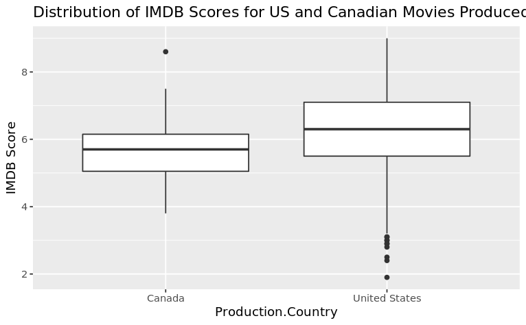

```r
# Select movies produced after 2010 by the United States or Canada
selected_movies <- shows_df %>%
  filter(Production.Country %in% c("United States", "Canada"),
         as.numeric(ifelse(Release.Date == "", 0, Release.Date)) > 2010,
         grepl("Movie", Content.Type))

# Draw boxplot of IMDB scores for US and Canadian movies
ggplot(selected_movies, aes(x = Production.Country, y = as.numeric(gsub("/10", "", Imdb.Score)))) +
  geom_boxplot() +
  ggtitle("Distribution of IMDB Scores for US and Canadian Movies Produced After 2010") +
  ylab("IMDB Score")
```

```r
# Display five values in each boxplot
by(selected_movies$Imdb.Score, selected_movies$Production.Country,
   FUN = function(x) {summary(as.numeric(gsub("/10", "", x)))})
```

```
selected_movies$Production.Country: Canada
   Min. 1st Qu.  Median    Mean 3rd Qu.    Max.
  3.800   5.050   5.700   5.747   6.150   8.600
---------------------------------------------------------
selected_movies$Production.Country: United States
   Min. 1st Qu.  Median    Mean 3rd Qu.    Max.
  1.900   5.500   6.300   6.218   7.100   9.000
```

## 1.7 To help a mother choose a good movie for her children who are less than 7 years old, you are required to: a) Propose a ranking with at least 2 criteria to rank the movies that best suit to their children (provide justification). b) Then write R code to find the top 5 movies based on your proposed ranking. (c) Write a short paragraph to discuss your insights and recommendations.

Answer: a) To propose a ranking with at least 2 criteria to rank the movies that best suit to children less than 7 years old, we can consider the following criteria:

Age-appropriateness: This criterion assesses whether a movie is suitable for children under 7 years of age based on its content, language, and themes. For example, movies with excessive violence, profanity, or sexual content may not be appropriate for young children.

Educational value: This criterion assesses the educational value of a movie for young children. For example, movies that teach children about important values such as kindness, empathy, and teamwork, or introduce them to new concepts or cultures can be beneficial for their learning and development.

2. To find the top 5 movies based on this ranking, we can use the following R code:

```r
# Filter movies suitable for children less than 7 years old
selected_movies <- shows_df %>%
  filter(grepl("TV-Y7", Rating)) %>%
  filter(grepl("Movie", Content.Type))

# Rank movies based on age-appropriateness and educational value
ranked_movies <- selected_movies %>%
  mutate(age_rank = ifelse(grepl("TV-Y", Rating) | grepl("TV-G", Rating) | grepl("TV-Y7", Rating), 1, 0),
         edu_rank = ifelse(grepl("Educational", Genres), 1, 0)) %>%
  mutate(rank = age_rank + edu_rank) %>%
  arrange(desc(rank), desc(as.numeric(gsub("/10", "", Imdb.Score)))) %>%
  select(Title, Release.Date, Rating, Genres, Imdb.Score)

# Display top 5 movies
head(ranked_movies, 5)
```

|  | Title | Release.Date | Rating | Genres | Imdb.Score |
| --- | --- | --- | --- | --- | --- |
| 1 | A truthful Mother | 2020 | TV-Y7 | Children & Family Movies | 8.1 |
| 2 | Arlo the Alligator Boy | 2021 | TV-Y7 | Children & Family Movies, Comedies, Music & Musicals | 7.1 |
| 3 | Buddy Thunderstruck: The Maybe Pile | 2017 | TV-Y7 | Children & Family Movies, Comedies | 6.9 |
| 4 | Rocko's Modern Life: Static Cling | 2019 | TV-Y7 | Children & Family Movies, Comedies, LGBTQ Movies | 6.9 |
| 5 | Lego DC Comics: Batman Be-Leaguered | 2014 | TV-Y7 | Movies | 6.7 |

## 2.1 Load the data from the Data worksheet into an R dataframe. Rename the columns to remove the word “Year” in the column names. Use glimpse to show the information of the data frame.

```r
# Load the data from the Data worksheet into an R dataframe, skipping the first two rows
library(readxl)

production_df <- read_excel("Production.xlsx", sheet = "Data", skip = 2)

# Rename the columns to remove the word "Year" in the column names
colnames(production_df) <- str_replace_all(colnames(production_df), "Year", "")

# Use glimpse to show the information of the data frame
glimpse(production_df)
```

```
Rows: 201
Columns: 6
$ `Production Country / Maturity Type` <chr> "Argentina / TV-14", "Argentin…
$ ` 2017`                              <chr> "1 - 7.5/10", NA, "1 - 4.1/10"…
$ ` 2018`                              <chr> "1 - 8.2/10", NA, "8 - 6.1/10"…
$ ` 2019`                              <chr> NA, "1 - 7.4/10", "7 - 6.0/10"…
$ ` 2020`                              <chr> "5 - 6.6/10", "1 - 7.8/10", "5…
$ ` 2021`                              <chr> NA, NA, NA, NA, NA, NA, NA, "1…
```

## 2.2 Transform the dataframe

### a) Use pivot_longer to transform the dataframe into three columns, namely “Production Country / Maturity Type”, “Year”, and “Value”. Drop all rows having NA in Value.

```r
# Use pivot_longer to transform the data
# Use pivot_longer to transform the data
production_df_transformed <- production_df %>%
  pivot_longer(cols = c(" 2017"," 2018"," 2019", " 2020", " 2021"), names_to = "Year", values_to = "Value") %>%
  drop_na(Value) # Drop rows with NA in Value column
```

### b) Split the first column into two columns and give meaningful column names to them.

```r
library(tidyr)

production_df <- production_df_transformed %>%
  separate(`Production Country / Maturity Type`,
           into = c("Production Country", "Maturity Type"),
           sep = " / ")
```

### c) Split column “Value” into two columns, namely “NumProducts” and “Score”. Remove the string “/10” in the Score column. Make sure they have correct data types

```r
production_df_transformed <- production_df %>%
  separate(Value, into = c("NumProducts", "Score"), sep = " - ") %>%
  mutate(Score = as.numeric(gsub("/10", "", Score)),
         NumProducts = as.integer(NumProducts))

glimpse(production_df_transformed)
```

```
Rows: 507
Columns: 5
$ `Production Country` <chr> "Argentina", "Argentina", "Argentina", "Argent…
$ `Maturity Type`      <chr> "TV-14", "TV-14", "TV-14", "TV-G", "TV-G", "TV…
$ Year                 <chr> " 2017", " 2018", " 2020", " 2019", " 2020", "…
$ NumProducts          <int> 1, 1, 5, 1, 1, 1, 8, 7, 5, 2, 1, 1, 3, 1, 1, 1…
$ Score                <dbl> 7.5, 8.2, 6.6, 7.4, 7.8, 4.1, 6.1, 6.0, 5.6, 6…
```

### d) Display the number of columns and rows after transformation.

```r
dim(production_df)
```

```
[1] 507   4
```

### e) Show the number of distinct countries and distinct years.

```r
# Number of distinct countries
distinct_countries <- distinct(production_df, `Production Country`, .keep_all = TRUE)
num_countries <- nrow(distinct_countries)
cat("Number of distinct countries:", num_countries, "\n")
```

```
Number of distinct countries: 68
```

```r
# Number of distinct years
distinct_years <- distinct(production_df, Year, .keep_all = TRUE)
num_years <- nrow(distinct_years)
cat("Number of distinct years:", num_years)
```

```
Number of distinct years: 5
```

## 2.3. What are the countries having the average score on all maturity types in 2021 from 6.8 to 7.0?

```r
library(dplyr)

production_df_transformed <- production_df_transformed %>%
  mutate(Year = as.numeric(trimws(Year)))


# Filter data for 2021
df_2021 <- production_df_transformed %>%
  filter(Year == "2021")

# Group data by country and calculate average score
df_avg_score <- df_2021 %>%
  group_by(`Production Country`) %>%
  summarize(avg_score = mean(as.numeric(Score)))

# Filter countries with average score between 6.8 and 7.0
df_filtered <- df_avg_score %>%
  filter(avg_score >= 6.8 & avg_score <= 7.0)

# Display the countries
df_filtered$`Production Country`
```

```
[1] "South Korea" "Thailand"    "Turkey"
```

## 2.4. Load the data from the Continent worksheet. Rename the columns to “Country”, “Continent”. How many countries/areas in total and how many do not appear in the Data worksheet?

```r
# Load the data from the "Continent" worksheet
continent_df <- read_excel("Production.xlsx", sheet = "Continent", skip = 2)

# Rename the columns
colnames(continent_df) <- c("Country or Area", "Continent")

# Count the total number of countries/areas
total_countries <- nrow(continent_df)

# Count the number of countries/areas that do not appear in the "Data" worksheet
missing_countries <- length(setdiff(continent_df$`Country or Area`, production_df$`Production Country`))

# Print the results
cat("Total number of countries/areas:", total_countries, "\n")
```

```
Total number of countries/areas: 249
```

```r
cat("Number of countries/areas missing in Data worksheet:", missing_countries, "\n")
```

```
Number of countries/areas missing in Data worksheet: 189
```

## 2.5 To help Netflix choose a Asian country to target in order to further grow their market, you are required to:

1. propose a criterion to rank the Asian countries to support their decision making (with justification).
2. Then write R code to find the top five countries based on your proposed ranking.
3. Draw a column/bar chart to compare these countries in terms of the measure you used for ranking. Order the result from the highest to the lowest value.
4. Write a short paragraph (less than 100 words) to describe your insights.

**Answer: a) A potential criterion to rank Asian countries for Netflix to target could be the number of productions made in each country. This could indicate the level of interest in the region for the types of content that Netflix produces, as well as the potential for future growth in the market.”**

**b) To find the top five countries based on the number of productions, we can use the production_df dataframe and filter for Asian countries, then group by country and count the number of non-NA values in the dataframe. We can then sort in descending order and select the top five countries.:**

```r
# Assuming the number of Netflix subscribers in each Asian country is stored in a column called "Subscribers"
library(dplyr)

# Filter for Asian countries
asian_countries <- c("China", "India", "Japan", "South Korea")

# Count number of productions for each country
top_countries <- production_df %>%
  filter(`Production Country` %in% asian_countries) %>%
  group_by(`Production Country`) %>%
  summarise(num_productions = sum(!is.na(Value))) %>%
  arrange(desc(num_productions)) %>%
  slice_head(n = 5)

top_countries
```

| Production Country | num_productions |
| --- | --- |
| India | 25 |
| Japan | 21 |
| South Korea | 17 |
| China | 12 |

```r
NA
NA
```

**c)To create a column/bar chart to compare these countries, we can use ggplot2. We can order the countries from highest to lowest number of productions to make it easier to compare.**

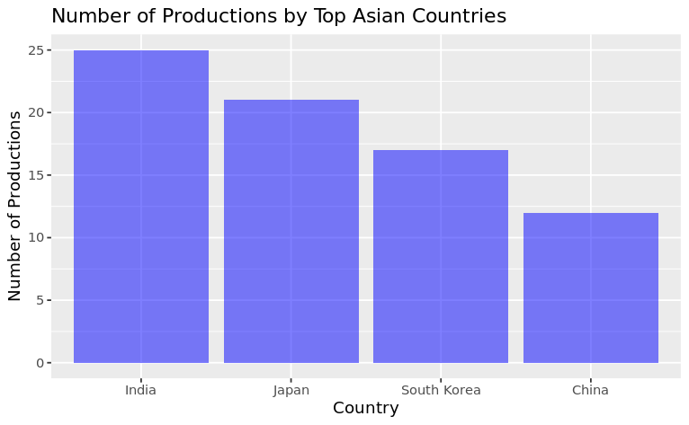

```r
library(ggplot2)

# Create bar chart of top countries
ggplot(top_countries, aes(x = reorder(`Production Country`, -num_productions), y = num_productions)) +
  geom_col(fill = "blue", alpha = 0.5) +
  labs(title = "Number of Productions by Top Asian Countries", x = "Country", y = "Number of Productions")
```

**d) From the analysis, we can see that India has the highest number of productions, followed by Japan and South Korea. China, despite being the most populous country in the region, only has a few productions listed in the dataset. This suggests that there may be an untapped market in China for Netflix to explore. Overall, this analysis suggests that India could be a good target for Netflix to further grow its market in Asia, as it has the highest number of productions and a large population.**